# Introduction to Logistic Regression

Jim Albert

4/28/2019

#### Outline

1. Several examples (predicting success in a class, predicting the chance of a hit based on several off-the-bat measurements)
2. Regression with a binary response - introduction to the logistic regression model
3. Making sense of the fitted model
4. Goodness of fit of a single model, comparing models
5. Residuals
6. Prediction – ROC curve

#### Illustrating logistic modeling for student grade example

```r
library(tidyverse)
```

### Getting started

Read in the data:

```r
d <- read_csv("ostat.csv")
head(d)
```

```
## # A tibble: 6 x 2
##   grade   sat
##   <dbl> <dbl>
## 1     2   525
## 2     2   533
## 3     4   545
## 4     2   582
## 5     3   581
## 6     4   576
```

Define a new Pass variable:

```r
d %>%
  mutate(Pass = ifelse(grade >= 3, 1, 0)) -> d
```

#### Fitting the logistic model:

```r
lfit <- glm(Pass ~ sat,
            family = binomial,
            data = d)
```

Extracting the coefficients:

```r
lfit %>% coef()
```

```
##  (Intercept)          sat
## -31.11467489   0.05784955
```

#### Prediction

Prediction on the linear component scale:

```r
predict(lfit) %>% head()
```

```
##          1          2          3          4          5          6
## -0.7436608 -0.2808644  0.4133302  2.5537636  2.4959141  2.2066663
```

Prediction on the response scale:

```r
predict(lfit, type = "response")
```

```
##          1          2          3          4          5          6
## 0.32220415 0.43024187 0.60188614 0.92782595 0.92385488 0.90084655
##          7          8          9         10         11         12
## 0.87817583 0.98394740 0.77263040 0.57386332 0.90084655 0.32220415
##         13         14         15         16         17         18
## 0.89002213 0.92782595 0.89002213 0.02048155 0.96462751 0.75166738
##         19         20         21         22         23         24
## 0.75166738 0.93520048 0.97172805 0.23032851 0.99838964 0.93520048
##         25         26         27         28         29         30
## 0.01299215 0.95582474 0.05294547 0.81070877 0.70601892 0.65582155
```

#### Graph fit

Defining the inverse logistic function and displaying the probability of success as a function of the covariate.

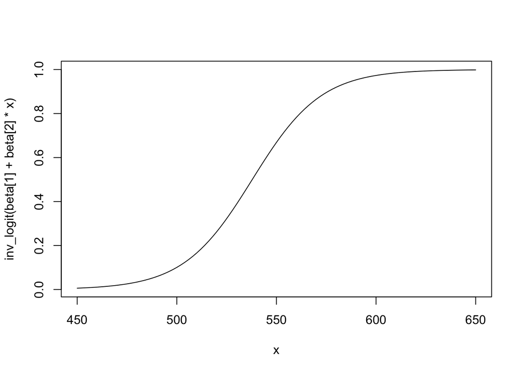

```r
inv_logit <- function(x){
  exp(x) / (1 + exp(x))
}
SAT <- seq(450, 650, by = 1)
beta <- coef(lfit)
curve(inv_logit(beta[1] + beta[2] * x),
      from = 450, to = 650)
```

#### Divide by 4 rule

Illustrate that the “divide by 4” rule of thumb works.

```r
diff(inv_logit(beta[1] + beta[2] * c(550, 551)))
```

```
## [1] 0.01268745
```

#### Comparing models

Illustrate comparing models by the “drop in deviance” test.

```r
lfit0 <- glm(Pass ~ 1,
            family = binomial,
            data = d)
deviance(lfit0)
```

```
## [1] 36.65186
```

```r
deviance(lfit)
```

```
## [1] 22.274
```

Add a random covariate.

```r
d %>%
  mutate(Male = rbinom(30, size = 1, prob = 0.5)) -> d
```

Is this new covariate significant?

```r
lfit2 <- glm(Pass ~ sat + Male,
            family = binomial,
            data = d)
deviance(lfit2)
```

```
## [1] 21.59427
```

#### Residual graph

Here is a basic graph of the residuals
$$R_i = y_i - \hat p_i$$

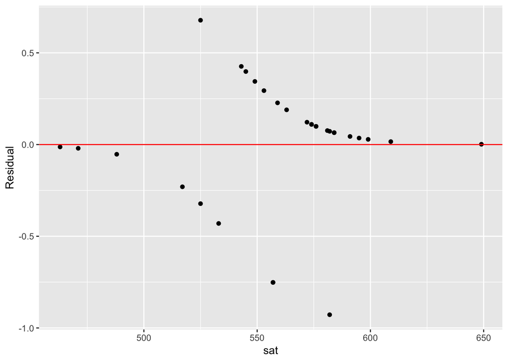

```r
d %>% mutate(Pred_Prob =
              predict(lfit, type = "response"),
             Residual = Pass - Pred_Prob) -> d
ggplot(d, aes(sat, Residual)) +
  geom_point() +
  geom_hline(yintercept = 0, color = "red")
```

#### ROC curve.

Suppose we predict that the student will succeed if the prediction probability is larger than 0.8; otherwise we predict failure.

```r
d %>% mutate(Prediction =
               ifelse(Pred_Prob > 0.8, 1, 0)) -> d
```

How good are our predictions on the observed data?

```r
d %>% group_by(Pass, Prediction) %>%
  count()
```

```
## # A tibble: 4 x 3
## # Groups:   Pass, Prediction [4]
##    Pass Prediction     n
##   <dbl>      <dbl> <int>
## 1     0          0     8
## 2     0          1     1
## 3     1          0     6
## 4     1          1    15
```

Here
$$P(\hat y = 1 | y = 0) = 1 / 9$$
$$P(\hat y = 1 | y = 1) = 15 / 21$$

ROC curve graphs two probabilities for many cutoff values – area under the area is a measure of goodness of the fitted model.

#### Example of ROC curves:

https://baseballwithr.wordpress.com/2018/01/09/hit-predictions-from-statcast-data/